# Test of significance for two population means

Mike Hitchman

10/01/2021

### The Scene

Suppose we want to test whether two population means are equal to each other,
$$H_o: \mu_1 - \mu_2 = 0 ~~~~~\text{ or, equivalently, }~~~~~ H_o: \mu_1 = \mu_2$$
against one of these three alternative hypotheses:

- $H_a: \mu_1 - \mu_2 > 0$ (one-sided, `greater` than)
- $H_a: \mu_1 - \mu_2 < 0$ (one-sided, `less` than )
- $H_a: \mu_1 - \mu_2 \neq 0$ (`two.sided`)

We assume the population standard deviations $\sigma_1$ and $\sigma_2$ are unknown, so we will use a t-distribution in our test.

### The Example

The silver content (% Ag) of a number of Byzantine coins discovered in Cyprus was determined. Nine of the coins came from the first coinage of the reign of King Manuel, I, Comnenus (1143-1180); and 7 of the coins came from a coinage many years later.

**The data**

```r
Ag1 <- c(5.9,6.8,6.4,7.0,6.6,7.7,7.2,6.9,6.2)
Ag2 <- c(5.3,5.6,5.5,5.1,6.2,5.8,5.8)
```

These data appear in *The Handbook of Small Data Sets* (p. 118), and are based on this article:

Hendy, M.F. and Charles J.A. (1970), *The production techniques, silver content and circulation history of the twelfth-century Byzantine Trachy.* Archaeonetry, 12. 13-21)

**The question**

Is there a signficant difference in the silver content of coins minted early and late in Manuel’s reign?

**The hypotheses**

We let $\mu_1$ denote the population mean silver content from the first coinage, and $\mu_2$ represent the population mean silver content from the later coinage. We translate our question to hypotheses for a test of significance:

$$\begin{cases}
H_o: \mu_1 = \mu_2\\
H_a: \mu_1 \neq \mu_2
\end{cases}$$

Equivalently, we can state the hypotheses as:
$$\begin{cases}
H_o: \mu_1 - \mu_2 = 0\\
H_a: \mu_1 - \mu_2 \neq 0
\end{cases}$$

We follow the Prepare-Check-Calculate-Conclude procedure to conduct the test.

**Prepare** for the significance test.

First sample:

```r
n_1 = length(Ag1)
xbar_1 = mean(Ag1)
s_1 = sd(Ag1)
```

$n_1$ = 9; $\bar{x}_1$ = 6.7444444; $s_1$ = 0.5433947

Second sample:

```r
n_2 = length(Ag2)
xbar_2 = mean(Ag2)
s_2 = sd(Ag2)
```

$n_2$ = 7; $\bar{x}_2$ = 5.6142857; $s_2$ = 0.3625308

**Check** It seems reasonable that % silver content in coins would follow a normal distribution, so these small sample sizes don’t prohibit a t-distribution from being a good model. We don’t see extreme values either:

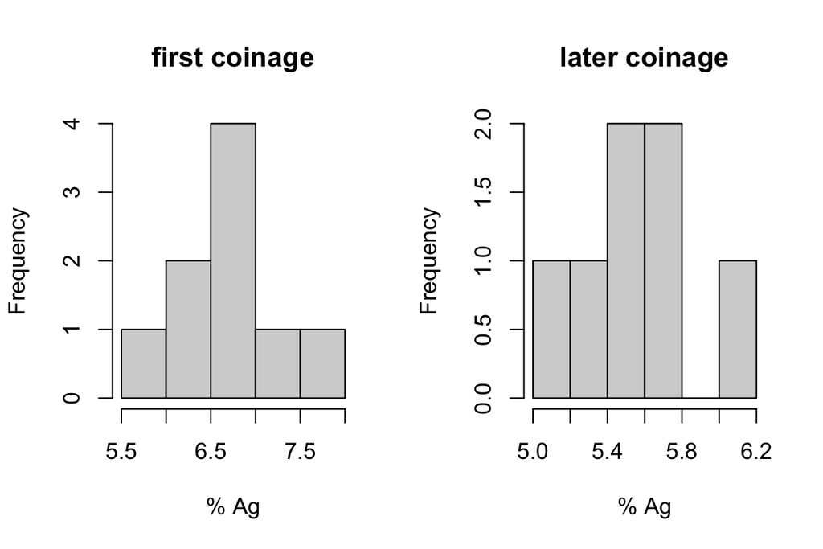

```r
par(mfrow=c(1,2))
hist(Ag1,main="first coinage",xlab="% Ag")
hist(Ag2,main="later coinage",xlab="% Ag")
```

**Calculate**

We find the test statistic from our data, which is a t-score in this case, and the p-value associated to this test statistic. We can ask RStudio to do the calculations, and note that the test statistic is given by the formula
$$t = \frac{\overline{x}_1-\overline{x}_2}{\sqrt{\frac{s_1^2}{n_1}+\frac{s_2^2}{n_2}}}.$$

```r
## Conducting a test of significance for two means

# Significance level
alpha=.05

## Data
  # Sample 1
Ag1 <- c(5.9, 6.8, 6.4, 7.0, 6.6, 7.7, 7.2, 6.9, 6.2) #data
n_1 = length(Ag1)
xbar_1 = mean(Ag1)
s_1 = sd(Ag1)
  # Sample 2
Ag2 <- c(5.3, 5.6, 5.5, 5.1, 6.2, 5.8, 5.8)  #data
n_2 = length(Ag2)
xbar_2 = mean(Ag2)
s_2 = sd(Ag2)

## standard error
SE = sqrt(s_1^2/n_1 + s_2^2/n_2)

## Test statistic
t = ((xbar_1-xbar_2)-0)/SE
df = min(n_1-1,n_2-1)

## P-value
p_val.lt = pt(t,df) # this is the p-value if H_a: mu < mu_0
p_val.gt = 1 - pt(t,df) # this is the p-value if H_a: mu > mu_0
p_val.neq = 2*(1-pt(abs(t),df)) # this is the p-value if H_a: mu not equal to mu_0

## Generating a Nice Output:
cat(paste0("Null hypthosis: mu_1 = mu_2","\n",
           "sample 1 mean = ",round(xbar_1,3),"\n",
           "sample 2 mean = ",round(xbar_2,3),"\n",
           "test statistic, t = ",round(t,3),"\n",
           "degrees of freedom (using smaller sample size - 1), df = ",df,"\n",
           "p-value for H_a: mu_1 - mu_2 < 0: ",p_val.lt,"\n",
           "p-value for H_a: mu_1 - mu_2 > 0: ",p_val.gt,"\n",
           "p-value for H_a: mu_1 not equal to mu_2: ",p_val.neq,"\n"))
```

```
## Null hypthosis: mu_1 = mu_2
## sample 1 mean = 6.744
## sample 2 mean = 5.614
## test statistic, t = 4.976
## degrees of freedom (using smaller sample size - 1), df = 6
## p-value for H_a: mu_1 - mu_2 < 0: 0.998744141238621
## p-value for H_a: mu_1 - mu_2 > 0: 0.00125585876137935
## p-value for H_a: mu_1 not equal to mu_2: 0.00251171752275869
```

In our example we used a two-sided alternative, so we obtain this p-value:

```r
(p_value=p_val.neq)
```

```
## [1] 0.002511718
```

**Conclude**:

Now, we compare this p-value to the significance level. In particular, we check whether

```r
p_value < alpha
```

```
## [1] TRUE
```

TRUE! Since the p-value is smaller than alpha, we reject H_0 in favor of H_a at the significance level 0.05. We have sufficient evidence to conclude that the average silver content of coins minted in these two eras is different.

### t.test()

The `t.test()` function reproduces the 2-sample t-test we conducted above, with one exception: this built-in R function uses a different value for df.

```r
t.test(Ag1,Ag2,  alternative="two.sided")
```

```
##
##  Welch Two Sample t-test
##
## data:  Ag1 and Ag2
## t = 4.976, df = 13.765, p-value = 0.0002138
## alternative hypothesis: true difference in means is not equal to 0
## 95 percent confidence interval:
##  0.6422519 1.6180655
## sample estimates:
## mean of x mean of y
##  6.744444  5.614286
```

Note that R’s built-in function results is the same test statistic as the one we produce following the formula in the book, but the df are different, which produces a different p-value than what we computed above. Here is the formula that the built-in function uses to determine df:

$$df = \frac{\left(\frac{s_1^2}{n_1} + \frac{s_2^2}{n_2} \right)^2}{\frac{1}{n_1 -1}\cdot \left(\frac{s_1^2}{n_1}\right)^2+\frac{1}{n_2 -1}\cdot \left(\frac{s_2^2}{n_2}\right)^2}$$

We can check that in this example this formula gives the df stated by the `t.test()` function:

```r
(s_1^2/n_1 + s_2^2/n_2)^2/((s_1^2/n_1)^2/(n_1-1)+(s_2^2/n_2)^2/(n_2-1))
```

```
## [1] 13.76548
```